# Practica 5

### Bienvenidos a la clase de regresión con Python

```python
import pandas as pd
import numpy as np
import matplotlib.pyplot as plt
import seaborn as seabornInstance
from sklearn.model_selection import train_test_split
from sklearn.linear_model import LinearRegression
from sklearn import metrics
%matplotlib inline


from sklearn import datasets, linear_model
#import statsmodels.api as sm
from scipy import stats
```

La presente práctica se devide inicialmente en dos sesiones, modelo de regresión lineal simple y modelo de regresión múltiple.

### Modelo de regresión lineal simple

A continuación se realiza el cargue del dataset.

```python
dataset = pd.read_csv('C:/Users/USUARIO/Documents/Monitoria_cda_2019_2/Clases_Python/Clase5_Python/Weather.csv')
```

Para determinar el tipo de variables.

```python
dataset.dtypes
```

```
STA              int64
Date            object
Precip          object
WindGustSpd    float64
MaxTemp        float64
MinTemp        float64
MeanTemp       float64
Snowfall        object
PoorWeather     object
YR               int64
MO               int64
DA               int64
PRCP            object
DR             float64
SPD            float64
MAX            float64
MIN            float64
MEA            float64
SNF             object
SND            float64
FT             float64
FB             float64
FTI            float64
ITH            float64
PGT            float64
TSHDSBRSGF      object
SD3            float64
RHX            float64
RHN            float64
RVG            float64
WTE            float64
dtype: object
```

Para determinar el tamaño del dataset

```python
dataset.shape
```

```
(119040, 31)
```

Análisis descriptivo de laas variables que se encuentran en el dataset

```python
dataset.describe()
```

|  | STA | WindGustSpd | MaxTemp | MinTemp | MeanTemp | YR | MO | DA | DR | SPD | ... | FT | FB | FTI | ITH | PGT | SD3 | RHX | RHN | RVG | WTE |
| --- | --- | --- | --- | --- | --- | --- | --- | --- | --- | --- | --- | --- | --- | --- | --- | --- | --- | --- | --- | --- | --- |
| count | 119040.000000 | 532.000000 | 119040.000000 | 119040.000000 | 119040.000000 | 119040.000000 | 119040.000000 | 119040.000000 | 533.000000 | 532.000000 | ... | 0.0 | 0.0 | 0.0 | 0.0 | 525.000000 | 0.0 | 0.0 | 0.0 | 0.0 | 0.0 |
| mean | 29659.435795 | 37.774534 | 27.045111 | 17.789511 | 22.411631 | 43.805284 | 6.726016 | 15.797530 | 26.998124 | 20.396617 | ... | NaN | NaN | NaN | NaN | 12.085333 | NaN | NaN | NaN | NaN | NaN |
| std | 20953.209402 | 10.297808 | 8.717817 | 8.334572 | 8.297982 | 1.136718 | 3.425561 | 8.794541 | 15.221732 | 5.560371 | ... | NaN | NaN | NaN | NaN | 5.731328 | NaN | NaN | NaN | NaN | NaN |
| min | 10001.000000 | 18.520000 | -33.333333 | -38.333333 | -35.555556 | 40.000000 | 1.000000 | 1.000000 | 2.000000 | 10.000000 | ... | NaN | NaN | NaN | NaN | 0.000000 | NaN | NaN | NaN | NaN | NaN |
| 25% | 11801.000000 | 29.632000 | 25.555556 | 15.000000 | 20.555556 | 43.000000 | 4.000000 | 8.000000 | 11.000000 | 16.000000 | ... | NaN | NaN | NaN | NaN | 8.500000 | NaN | NaN | NaN | NaN | NaN |
| 50% | 22508.000000 | 37.040000 | 29.444444 | 21.111111 | 25.555556 | 44.000000 | 7.000000 | 16.000000 | 32.000000 | 20.000000 | ... | NaN | NaN | NaN | NaN | 11.600000 | NaN | NaN | NaN | NaN | NaN |
| 75% | 33501.000000 | 43.059000 | 31.666667 | 23.333333 | 27.222222 | 45.000000 | 10.000000 | 23.000000 | 34.000000 | 23.250000 | ... | NaN | NaN | NaN | NaN | 15.000000 | NaN | NaN | NaN | NaN | NaN |
| max | 82506.000000 | 75.932000 | 50.000000 | 34.444444 | 40.000000 | 45.000000 | 12.000000 | 31.000000 | 78.000000 | 41.000000 | ... | NaN | NaN | NaN | NaN | 23.900000 | NaN | NaN | NaN | NaN | NaN |

8 rows × 24 columns

A continuación, se realiza un scatterplot sobre las dos variables.

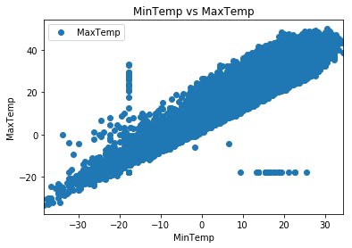

```python
dataset.plot(x='MinTemp', y='MaxTemp', style='o')
plt.title('MinTemp vs MaxTemp')
plt.xlabel('MinTemp')
plt.ylabel('MaxTemp')
plt.show()
```

A continuaciòn se estudia la variable MaxTemp, y se puede determinar que el dpromedio està entre el intervalo 25 y 35

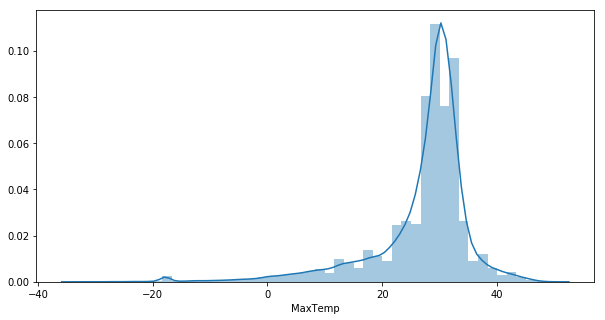

```python
plt.figure(figsize=(10,5))
plt.tight_layout()
seabornInstance.distplot(dataset['MaxTemp'])
```

A continuación se va a estimar un modelo donde la variable respuesta es MxTemp y la variable explicativa es MinTemp, para tal fin, se define la variable X y la variable y de la siguiente forma

```python
X = dataset['MinTemp'].values.reshape(-1,1)
y = dataset['MaxTemp'].values.reshape(-1,1)
```

```python
X
```

```
array([[22.22222222],
       [21.66666667],
       [22.22222222],
       ...,
       [18.33333333],
       [18.33333333],
       [17.22222222]])
```

```python
y
```

```
array([[25.55555556],
       [28.88888889],
       [26.11111111],
       ...,
       [28.33333333],
       [28.33333333],
       [29.44444444]])
```

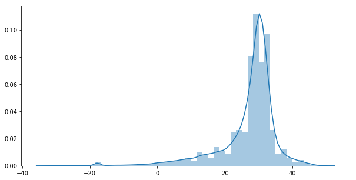

```python
plt.figure(figsize=(10,5))
plt.tight_layout()
seabornInstance.distplot(y)
```

A continuación se realiza una partición de la data, se tomará 80% como entrenamiento y 20% como test

```python
X_train, X_test, y_train, y_test = train_test_split(X, y, test_size=0.2, random_state=0)
```

A continuación se estima el modelo

```python
regressor = LinearRegression()
regressor.fit(X_train, y_train) #training the algorithm
```

```
LinearRegression(copy_X=True, fit_intercept=True, n_jobs=None, normalize=False)
```

```python
regressor
```

```
LinearRegression(copy_X=True, fit_intercept=True, n_jobs=None, normalize=False)
```

Para imprimir los coeficientes betas estimados

```python
#To retrieve the intercept:
print(regressor.intercept_)

#For retrieving the slope:
print(regressor.coef_)
```

```
[10.66185201]
[[0.92033997]]
```

### ¿Cómo se interpreta estos resultados?

A continuación se va aplicar el modelo sobre los datos de test.

```python
y_pred = regressor.predict(X_test)
```

```python
y_pred
```

```
array([[33.67035117],
       [30.0912513 ],
       [26.51215143],
       ...,
       [32.64775121],
       [30.60255128],
       [31.62515124]])
```

A continuación, se realiza una medición de este modelo.

```python
df = pd.DataFrame({'Actual': y_test.flatten(), 'Predicted': y_pred.flatten()})
df
```

|  | Actual | Predicted |
| --- | --- | --- |
| 0 | 28.888889 | 33.670351 |
| 1 | 31.111111 | 30.091251 |
| 2 | 27.222222 | 26.512151 |
| 3 | 28.888889 | 31.113851 |
| 4 | 23.333333 | 15.774852 |
| 5 | 37.222222 | 30.602551 |
| 6 | 22.222222 | 11.684452 |
| 7 | 35.555556 | 33.670351 |
| 8 | 30.555556 | 30.602551 |
| 9 | 28.888889 | 32.647751 |
| 10 | 24.444444 | 29.068651 |
| 11 | 22.777778 | 23.955652 |
| 12 | 30.555556 | 30.091251 |
| 13 | 26.111111 | 26.000851 |
| 14 | 27.222222 | 29.068651 |
| 15 | 30.555556 | 32.647751 |
| 16 | 10.555556 | 15.774852 |
| 17 | 32.222222 | 32.136451 |
| 18 | 29.444444 | 29.579951 |
| 19 | 23.333333 | 18.842652 |
| 20 | 30.555556 | 26.000851 |
| 21 | 43.333333 | 31.113851 |
| 22 | 27.222222 | 30.091251 |
| 23 | 33.333333 | 33.159051 |
| 24 | 31.111111 | 22.421752 |
| 25 | 30.000000 | 31.113851 |
| 26 | 33.333333 | 30.602551 |
| 27 | 31.111111 | 30.602551 |
| 28 | 33.333333 | 35.204251 |
| 29 | 36.111111 | 30.091251 |
| ... | ... | ... |
| 23778 | 4.444444 | 9.639252 |
| 23779 | 31.111111 | 32.136451 |
| 23780 | 30.000000 | 32.136451 |
| 23781 | 34.444444 | 30.091251 |
| 23782 | 28.888889 | 32.647751 |
| 23783 | 32.222222 | 29.068651 |
| 23784 | 25.000000 | 15.774852 |
| 23785 | 26.666667 | 30.091251 |
| 23786 | 35.000000 | 32.136451 |
| 23787 | 15.000000 | 12.195752 |
| 23788 | 19.444444 | 22.421752 |
| 23789 | 15.000000 | 19.865252 |
| 23790 | 33.333333 | 25.489551 |
| 23791 | 27.777778 | 26.000851 |
| 23792 | 31.666667 | 30.091251 |
| 23793 | 31.666667 | 31.625151 |
| 23794 | 29.444444 | 31.113851 |
| 23795 | 29.444444 | 33.670351 |
| 23796 | 16.666667 | 17.820052 |
| 23797 | 20.000000 | 21.399152 |
| 23798 | 28.888889 | 32.136451 |
| 23799 | 31.111111 | 30.091251 |
| 23800 | 44.444444 | 35.715551 |
| 23801 | 36.666667 | 36.226851 |
| 23802 | 29.444444 | 33.159051 |
| 23803 | 32.777778 | 32.136451 |
| 23804 | 32.222222 | 29.068651 |
| 23805 | 31.111111 | 32.647751 |
| 23806 | 31.111111 | 30.602551 |
| 23807 | 36.666667 | 31.625151 |

23808 rows × 2 columns

A continuación se muestra el siguiente gráfico que permite comparar la estimación respecto al valor obsservado en la data de test.

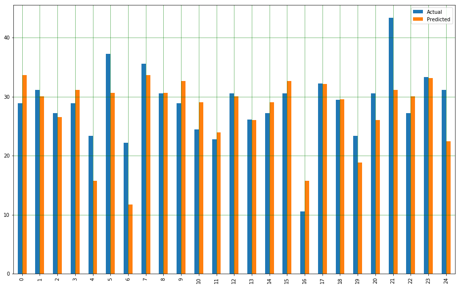

```python
df1 = df.head(25)
df1.plot(kind='bar',figsize=(16,10))
plt.grid(which='major', linestyle='-', linewidth='0.5', color='green')
plt.grid(which='minor', linestyle=':', linewidth='0.5', color='black')
plt.show()
```

A continuación se obtienen las medidas de error al aplicar el modelo.

```python
print('Mean Absolute Error:', metrics.mean_absolute_error(y_test, y_pred))
print('Mean Squared Error:', metrics.mean_squared_error(y_test, y_pred))
print('Root Mean Squared Error:', np.sqrt(metrics.mean_squared_error(y_test, y_pred)))
```

```
Mean Absolute Error: 3.19932917837853
Mean Squared Error: 17.631568097568447
Root Mean Squared Error: 4.198996082109204
```

Finalmente, se muestra un gráfico que permite observar el modelo de regresiòn ajustado.

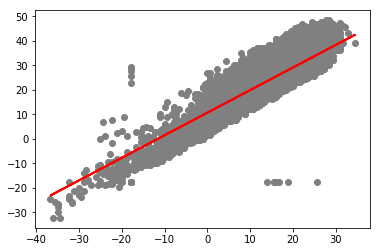

```python
plt.scatter(X_test, y_test,  color='gray')
plt.plot(X_test, y_pred, color='red', linewidth=2)
plt.show()
```

## Modelo de regresión múltiple

Los datos para esta práctica se encuentran en el siguiente link: https://www.kaggle.com/mirichoi0218/insurance

A continuación se cargan los datos.

```python
dataset = pd.read_csv('insurance.csv')
```

```python
dataset.dtypes
```

```
age           int64
sex          object
bmi         float64
children      int64
smoker       object
region       object
charges     float64
dtype: object
```

Determinar el tamaño del dataframe

```python
dataset.shape
```

```
(1338, 7)
```

Para realziar un análisis descriptivo sobre el dataset

```python
dataset.describe()
```

|  | age | bmi | children | charges |
| --- | --- | --- | --- | --- |
| count | 1338.000000 | 1338.000000 | 1338.000000 | 1338.000000 |
| mean | 39.207025 | 30.663397 | 1.094918 | 13270.422265 |
| std | 14.049960 | 6.098187 | 1.205493 | 12110.011237 |
| min | 18.000000 | 15.960000 | 0.000000 | 1121.873900 |
| 25% | 27.000000 | 26.296250 | 0.000000 | 4740.287150 |
| 50% | 39.000000 | 30.400000 | 1.000000 | 9382.033000 |
| 75% | 51.000000 | 34.693750 | 2.000000 | 16639.912515 |
| max | 64.000000 | 53.130000 | 5.000000 | 63770.428010 |

Identifiquemos cuáles so las variables que tienen algún Na

```python
dataset.isnull().any()
```

```
age         False
sex         False
bmi         False
children    False
smoker      False
region      False
charges     False
dtype: bool
```

```python
dataset = dataset.fillna(method='ffill')
```

A continuación, se construye la matriz X y el vector y, los cuales contiene las variables explicativas y la variable respuesta:

```python
X = dataset.drop(['charges'],axis=1)
y = dataset['charges']
```

```python
X.head()
```

|  | age | sex | bmi | children | smoker | region |
| --- | --- | --- | --- | --- | --- | --- |
| 0 | 19 | female | 27.900 | 0 | yes | southwest |
| 1 | 18 | male | 33.770 | 1 | no | southeast |
| 2 | 28 | male | 33.000 | 3 | no | southeast |
| 3 | 33 | male | 22.705 | 0 | no | northwest |
| 4 | 32 | male | 28.880 | 0 | no | northwest |

Analicemos la variable charges

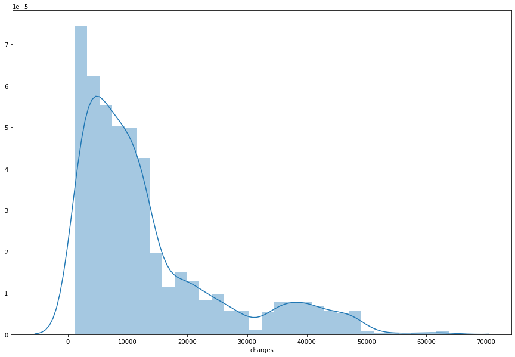

```python
plt.figure(figsize=(15,10))
plt.tight_layout()
seabornInstance.distplot(dataset['charges'])
```

Y tambien analicemos como se comportan las variables explicativas y la variable de respuesta.

[output not shown]

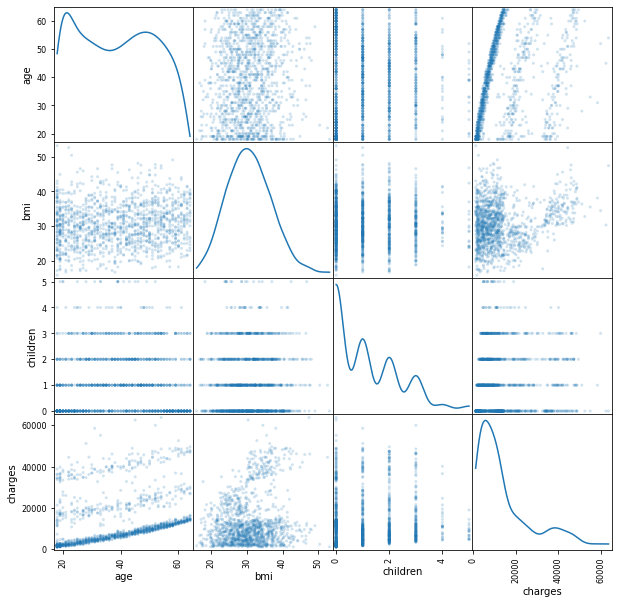

```python
from pandas.plotting import scatter_matrix

scatter_matrix(dataset, alpha=0.2, figsize=(10, 10), diagonal='kde')
```

Como saben, la regresión lineal solo acepta variables numéricas. ¿Qué hacemos con las variables categóricas? ¿Influiran en el problema?.  
Para incluirlas, hay que transformarlas a números.

```python
X = pd.get_dummies(X)
X.head()
```

|  | age | bmi | children | sex_female | sex_male | smoker_no | smoker_yes | region_northeast | region_northwest | region_southeast | region_southwest |
| --- | --- | --- | --- | --- | --- | --- | --- | --- | --- | --- | --- |
| 0 | 19 | 27.900 | 0 | 1 | 0 | 0 | 1 | 0 | 0 | 0 | 1 |
| 1 | 18 | 33.770 | 1 | 0 | 1 | 1 | 0 | 0 | 0 | 1 | 0 |
| 2 | 28 | 33.000 | 3 | 0 | 1 | 1 | 0 | 0 | 0 | 1 | 0 |
| 3 | 33 | 22.705 | 0 | 0 | 1 | 1 | 0 | 0 | 1 | 0 | 0 |
| 4 | 32 | 28.880 | 0 | 0 | 1 | 1 | 0 | 0 | 1 | 0 | 0 |

A continuación, se realiza una partición sobre la data, paa efectos de este ejercicio, se tomará 80% como entrenamiento y 20% como test.

```python
X_train, X_test, y_train, y_test = train_test_split(X, y, test_size=0.2, random_state=0)
display(X_train.head())
display(y_train.head())
```

|  | age | bmi | children | sex_female | sex_male | smoker_no | smoker_yes | region_northeast | region_northwest | region_southeast | region_southwest |
| --- | --- | --- | --- | --- | --- | --- | --- | --- | --- | --- | --- |
| 621 | 37 | 34.100 | 4 | 0 | 1 | 0 | 1 | 0 | 0 | 0 | 1 |
| 194 | 18 | 34.430 | 0 | 0 | 1 | 1 | 0 | 0 | 0 | 1 | 0 |
| 240 | 23 | 36.670 | 2 | 1 | 0 | 0 | 1 | 1 | 0 | 0 | 0 |
| 1168 | 32 | 35.200 | 2 | 0 | 1 | 1 | 0 | 0 | 0 | 0 | 1 |
| 1192 | 58 | 32.395 | 1 | 1 | 0 | 1 | 0 | 1 | 0 | 0 | 0 |

```
621     40182.24600
194      1137.46970
240     38511.62830
1168     4670.64000
1192    13019.16105
Name: charges, dtype: float64
```

A continuación se estima el modelo

```python
regressor = LinearRegression()
regressor.fit(X_train, y_train)
```

```
LinearRegression()
```

```python
regressor
```

```
LinearRegression()
```

A continuación, se imprimen los coeficientes estimados beta.

```python
print(regressor.intercept_)
```

```
-517.1368358425661
```

```python
coeff_df = pd.DataFrame(zip(X.columns,regressor.coef_))
coeff_df
```

|  | 0 | 1 |
| --- | --- | --- |
| 0 | age | 253.700500 |
| 1 | bmi | 335.962814 |
| 2 | children | 436.910121 |
| 3 | sex_female | 7.731864 |
| 4 | sex_male | -7.731864 |
| 5 | smoker_no | -11802.508634 |
| 6 | smoker_yes | 11802.508634 |
| 7 | region_northeast | 483.840068 |
| 8 | region_northwest | 223.707336 |
| 9 | region_southeast | -429.438766 |
| 10 | region_southwest | -278.108638 |

### ¿Cómo se interpretan los resultados anteriores?

A continuación, se aplica el modelo estiado sobre los datos de test.

```python
y_pred = regressor.predict(X_test)
```

```python
df = pd.DataFrame({'Actual': y_test, 'Predicted': y_pred})
df1 = df.head(25)
df1
```

|  | Actual | Predicted |
| --- | --- | --- |
| 578 | 9724.53000 | 11169.927119 |
| 610 | 8547.69130 | 9486.709085 |
| 569 | 45702.02235 | 38181.123053 |
| 1034 | 12950.07120 | 16266.313289 |
| 198 | 9644.25250 | 6914.648007 |
| 981 | 4500.33925 | 3963.484876 |
| 31 | 2198.18985 | 1579.396913 |
| 1256 | 11436.73815 | 14385.256569 |
| 1219 | 7537.16390 | 9012.579696 |
| 1320 | 5425.02335 | 7508.460677 |
| 613 | 6753.03800 | 4491.767282 |
| 1107 | 10493.94580 | 10279.583941 |
| 1263 | 7337.74800 | 8801.297506 |
| 406 | 4185.09790 | 3798.020130 |
| 795 | 18310.74200 | 27926.200966 |
| 970 | 10702.64240 | 10715.115820 |
| 824 | 12523.60480 | 11288.975621 |
| 141 | 3490.54910 | 6105.017680 |
| 1173 | 6457.84340 | 8241.041174 |
| 1042 | 33475.81715 | 27144.508950 |
| 966 | 23967.38305 | 33644.090970 |
| 467 | 12643.37780 | 14355.104327 |
| 1098 | 23045.56616 | 11737.204332 |
| 757 | 23065.42070 | 32137.433498 |
| 1097 | 1674.63230 | 4170.059130 |

A continuación, se realiza un gráfico que permite comparar el valor estimado y el observado, sobre algunas observaciones

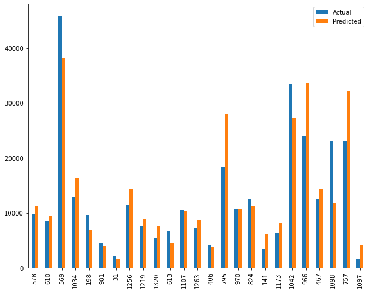

```python
df1.plot(kind='bar',figsize=(10,8))

plt.show()
```

Finalmente, se imprimen algunas métricas.

```python
print('Mean Absolute Error:', metrics.mean_absolute_error(y_test, y_pred))
print('Mean Squared Error:', metrics.mean_squared_error(y_test, y_pred))
print('Root Mean Squared Error:', np.sqrt(metrics.mean_squared_error(y_test, y_pred)))
print('R^2:', metrics.r2_score(y_test, y_pred))
```

```
Mean Absolute Error: 3933.2726494052367
Mean Squared Error: 31827950.22952384
Root Mean Squared Error: 5641.62655885019
R^2: 0.7999876970680433
```

### Análisis

1. ¿Qué significado tiene el intercepto? ¿Tiene sentido ser analizado para este problema?
2. ¿Qué significado tienen los coeficientes que acompañan a las variables categóricas? (i.e smoker_no, smoker_yes)
3. Realice la estimación de la variable respuesta pero solo con las variables numéricas. ¿Cuál modelo utilizaría para predecir la prima del seguro? ¿Por qué?